# Actividad Práctica 2

# Técnicas de aprendizaje profundo

# Parte 2: Redes neuronales recurrentes

# Actividades

## Explorar los datos

```python
import pandas as pd
import os, sys
import matplotlib.pyplot as plt
%matplotlib inline
plt.style.use('ggplot')

# config looks
plt.rcParams['figure.figsize'] = (20.0,15.0)
plt.rcParams['font.size'] = 22
plt.style.use('seaborn-whitegrid')
plt.rcParams['lines.linewidth'] = 2
```

```python
path_assets = os.path.abspath(os.path.join(os.getcwd(),'..'))
df = pd.read_csv(os.path.join(path_assets, os.path.normpath('assets/international-airline-passengers.csv')))
df.head()
```

|  | Month | International airline passengers: monthly totals in thousands. Jan 49 ? Dec 60 |
| --- | --- | --- |
| 0 | 1949-01 | 112.0 |
| 1 | 1949-02 | 118.0 |
| 2 | 1949-03 | 132.0 |
| 3 | 1949-04 | 129.0 |
| 4 | 1949-05 | 121.0 |

```python
df.describe()
```

|  | International airline passengers: monthly totals in thousands. Jan 49 ? Dec 60 |
| --- | --- |
| count | 144.000000 |
| mean | 280.298611 |
| std | 119.966317 |
| min | 104.000000 |
| 25% | 180.000000 |
| 50% | 265.500000 |
| 75% | 360.500000 |
| max | 622.000000 |

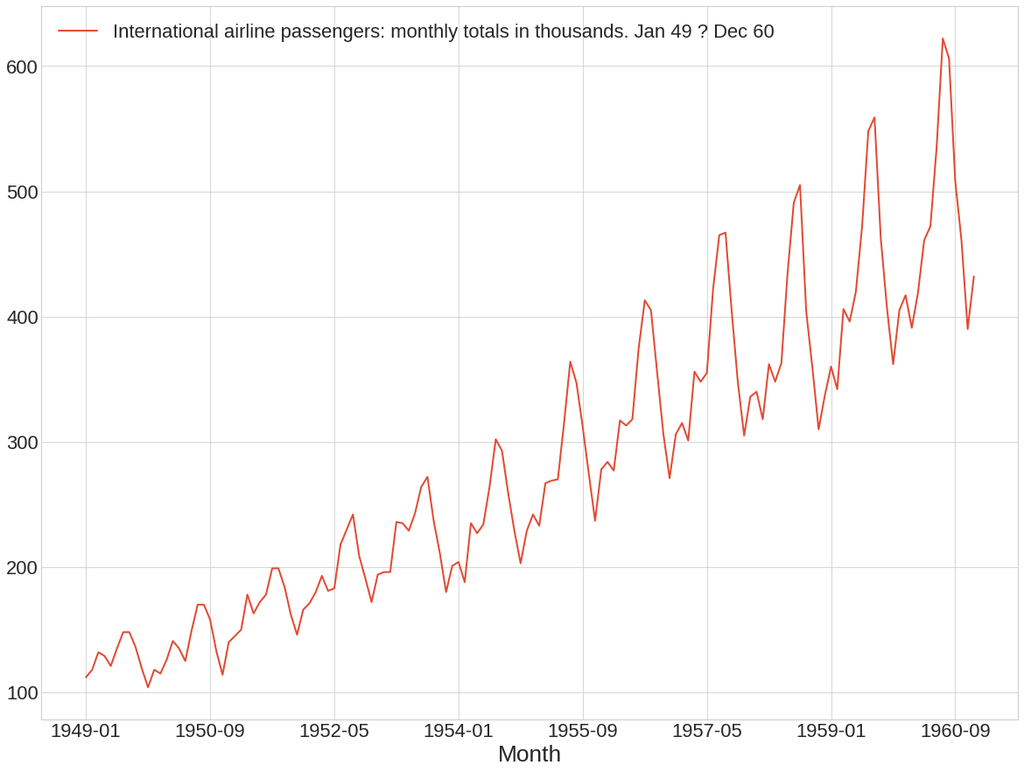

```python
df.plot.line(x=df.columns[0], y=df.columns[1])
```

El gráfico muestra el total mensual de pasajeros en vuelos internacionales en EE.UU para el perı́odo Enero 1949 a Diciembre 1960. Las cifras están en miles de pasajeros por mes.

La tendencia creciente de la curva muestra el aumento de pasajeros a lo largo de los años. Adicionalmente, cada año presenta *peaks* característicos causados por aumentos puntuales de la demanda debido al perı́odo de vacaciones y festividades especiales.

Se intentará predecir en el tiempo la cantidad de pasajeros, usando RNN.

## RNN

```python
# Definicion de librerias con la funciones que seran utilizadas por Keras.
import keras
from keras.layers import Activation, Dense, Flatten, Dropout
from keras.models import Sequential
from keras.layers.recurrent import SimpleRNN
from keras.layers.convolutional import Convolution2D, ZeroPadding2D, Conv2D
from keras.layers.normalization import BatchNormalization
from keras.layers.pooling import MaxPooling2D
```

```python
# nueva instancia de red secuencial
modelRNN = Sequential()
```

```python
# capa con una RNN
modelRNN.add(SimpleRNN(5, input_shape=(4,1), return_sequences=False))
```

Se reescribió la función debido a la sugerencia contenida en la nueva versión de la API de `keras`:

En este caso, se tiene que

- El primer término según la documentación corresponde a `units`, lo que sería la dimensionalidad de $h_t=5$.
- `input_dim` es el equivalente a la dimensión de los datos $x_t$ de entrada. En este caso es la demanda mensual, la cual sólo requiere de una dimensión.
- `input_length` es el equivalente al largo de la secuencia de entrada. Para este caso, se consideran cuatro meses por lo que su valor es 4
- El término `return_sequences=False` indica que el valor la salida $y_t$ se calcula sólo en la última unidad

La red resultante gráficamente tiene la siguiente forma

[figure not shown]

## Actividad 8

Considerando los parámetros $W$ de la red según este diagrama, se tiene que

- $W_{xh}$ tiene dimensionalidad $5\times1$
- $W_{hh}$ tiene dimensionalidad $5\times5$
- $W_{hy}$ tiene dimensionalidad $5\times1$

Esto suma en total 35 parámetros

```python
modelRNN.summary()
```

```
_________________________________________________________________
Layer (type)                 Output Shape              Param #
=================================================================
simple_rnn_1 (SimpleRNN)     (None, 5)                 35
=================================================================
Total params: 35
Trainable params: 35
Non-trainable params: 0
_________________________________________________________________
```

Si se desea cambiar la dimensionalidad de $h_t$ a $4$, según el análisis anterior

- $W_{xh}$ tiene dimensionalidad $4\times1$
- $W_{hh}$ tiene dimensionalidad $4\times4$
- $W_{hy}$ tiene dimensionalidad $4\times1$

La dimensionalidad se ve reducida a $4+16+4=24$ unidades.

```python
# nueva instancia de red secuencial
modelRNN_temp = Sequential()
```

```python
modelRNN_temp.add(SimpleRNN(4, input_shape=(4,1), return_sequences=False))
```

```python
modelRNN_temp.summary()
```

```
_________________________________________________________________
Layer (type)                 Output Shape              Param #
=================================================================
simple_rnn_2 (SimpleRNN)     (None, 4)                 24
=================================================================
Total params: 24
Trainable params: 24
Non-trainable params: 0
_________________________________________________________________
```

Donde $n$ es la dimensión de $x$ y $d$ es la cantidad de unidades.

Finalmente, dado que se desea predecir una variable de la misma dimensionalidad que la entrada, basta con agregar una capa densa de una neurona, sin función de activación

```python
modelRNN.add(Dense(1))
```

## Actividad 9

Sin información

## Actividad 10

Se crea el siguiente script en la carpeta `./scripts/AirlinePrediction.py`. Dado que el resultado es extenso, se implementa un logger y donde se asignarán letras a cada ensayo, tal que

- A es la red original
- B es la red con `history=10`, es decir `input_shape(10,1)`
- C es la red con `Dense(100)` antes de `Dense(1)`
- D es la red con `Dropout(0.5)` antes de `Dense(1)`

Se omite el output debido a que el código está diseñado para correr usando CLI, y los resultados pueden verse en el archivo `trace.log`.

```
#%load ../scripts/AirlinePrediction.py
from keras.models import Sequential
from keras.layers import Dense, Dropout, TimeDistributed, Flatten, SimpleRNN,LSTM
import airlineUtils
import logging
from logger import set_logger

set_logger()
logger = logging.getLogger(__name__)


logger.debug('Test case: SimpleRNN')

for case in  ['a','b','c','d']:

    logger.debug('Running case %s',case)
    #set sequence length
    if case == 'b':
        history=10
    else:
        history=4

    #read training and test sets
    trainX, trainY, testX, testY, scaler, dataset=airlineUtils.readAirlineData(history)

    # create and fit the LSTM network
    modelRNN = Sequential()
    modelRNN.add(SimpleRNN(5,input_shape=(history,1), return_sequences=False))

    if case=='c':
        modelRNN.add(Dense(100)) # ACTIVIDAD 10

    if case=='d':
        modelRNN.add(Dropout(0.5))

    #
    modelRNN.add(Dense(1))

    #Train model
    modelRNN.compile(loss='mean_squared_error', optimizer='adam')
    modelRNN.fit(trainX, trainY, epochs=150, batch_size=5, verbose=2)

    # Make predictions
    trainPredict = modelRNN.predict(trainX)
    testPredict = modelRNN.predict(testX)

    #Display results
    airlineUtils.displayResult(dataset, trainPredict, trainY, testPredict, testY, scaler, history, filename='simplernn_'+case)
```

La ejecución repetida del script se logra a través de un loop en `bash` simple:

```
for i in {1..5}; do python AirlinePrediction.py; done
```

Donde una sola ejecución da como resultado un log

[output not shown]

Los resultados, parseados, se graficarán más adelante.

```python
parameters = {'simple_rnn':{},'lstm':{}}
```

### Caso A

Caso default con `input_shape=(4,1)`

```python
del modelRNN
modelRNN = Sequential()
modelRNN.add(SimpleRNN(5,input_shape=(4,1),return_sequences=False))
modelRNN.add(Dense(1))
modelRNN.summary()
```

```
_________________________________________________________________
Layer (type)                 Output Shape              Param #
=================================================================
simple_rnn_4 (SimpleRNN)     (None, 5)                 35
_________________________________________________________________
dense_10 (Dense)             (None, 1)                 6
=================================================================
Total params: 41
Trainable params: 41
Non-trainable params: 0
_________________________________________________________________
```

```python
# añadir los parámetros
parameters['simple_rnn']['a'] = modelRNN.count_params()
```

### Caso B

Al cambiar el parámetro `history=4` por `history=10` se tiene

```python
del modelRNN
modelRNN = Sequential()
modelRNN.add(SimpleRNN(5,input_shape=(10,1),return_sequences=False))
modelRNN.add(Dense(1))
modelRNN.summary()
```

```
_________________________________________________________________
Layer (type)                 Output Shape              Param #
=================================================================
simple_rnn_5 (SimpleRNN)     (None, 5)                 35
_________________________________________________________________
dense_11 (Dense)             (None, 1)                 6
=================================================================
Total params: 41
Trainable params: 41
Non-trainable params: 0
_________________________________________________________________
```

```python
# añadir los parámetros
parameters['simple_rnn']['b'] = modelRNN.count_params()
```

### Caso C

Se agrega una capa densa de 100 unidades

```python
del modelRNN
modelRNN = Sequential()
modelRNN.add(SimpleRNN(5,input_shape=(4,1),return_sequences=False))
modelRNN.add(Dense(100))
modelRNN.add(Dense(1))
modelRNN.summary()
```

```
_________________________________________________________________
Layer (type)                 Output Shape              Param #
=================================================================
simple_rnn_6 (SimpleRNN)     (None, 5)                 35
_________________________________________________________________
dense_12 (Dense)             (None, 100)               600
_________________________________________________________________
dense_13 (Dense)             (None, 1)                 101
=================================================================
Total params: 736
Trainable params: 736
Non-trainable params: 0
_________________________________________________________________
```

```python
# añadir los parámetros
parameters['simple_rnn']['c'] = modelRNN.count_params()
```

### Caso D

Finalmente, al agregar una capa con `Dropout()` se tiene

```python
del modelRNN
modelRNN = Sequential()
modelRNN.add(SimpleRNN(5,input_shape=(4,1),return_sequences=False))
modelRNN.add(Dropout(0.5))
modelRNN.add(Dense(1))
modelRNN.summary()
```

```
_________________________________________________________________
Layer (type)                 Output Shape              Param #
=================================================================
simple_rnn_7 (SimpleRNN)     (None, 5)                 35
_________________________________________________________________
dropout_2 (Dropout)          (None, 5)                 0
_________________________________________________________________
dense_14 (Dense)             (None, 1)                 6
=================================================================
Total params: 41
Trainable params: 41
Non-trainable params: 0
_________________________________________________________________
```

```python
# añadir los parámetros
parameters['simple_rnn']['d'] = modelRNN.count_params()
```

### RMSE de SimpleRNN

```python
test_simple = pd.read_csv('./assets/normalRNN.csv')
```

```python
test_simple.head()
```

|  | trainA | testA | trainB | testB | trainC | testC | trainD | testD |
| --- | --- | --- | --- | --- | --- | --- | --- | --- |
| 0 | 21.91 | 46.80 | 22.36 | 57.13 | 22.09 | 46.71 | 31.54 | 83.60 |
| 1 | 21.43 | 54.20 | 21.80 | 67.79 | 22.57 | 44.77 | 30.25 | 82.93 |
| 2 | 21.66 | 46.47 | 18.28 | 44.50 | 21.85 | 48.42 | 25.67 | 62.99 |
| 3 | 22.17 | 62.59 | 19.61 | 40.57 | 21.35 | 51.81 | 33.70 | 95.03 |
| 4 | 22.22 | 61.48 | 19.48 | 46.26 | 21.18 | 52.12 | 29.99 | 80.83 |

```python
test_simple_train = test_simple[['trainA','trainB','trainC','trainD']]
```

```
Text(0.5,1,'RMSE Score of SimpleRNN during training')
```

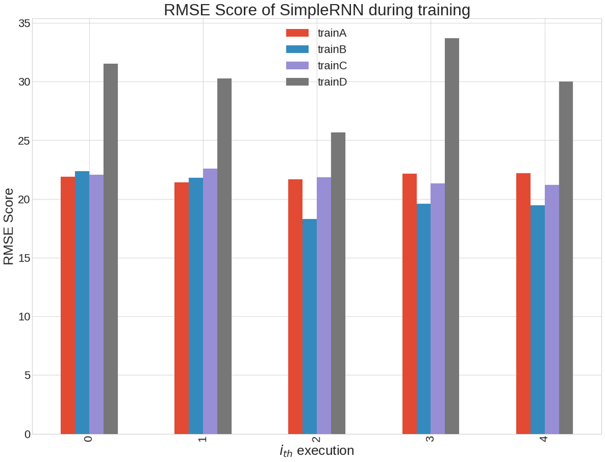

```python
# tiempos de training
ax = test_simple_train.plot.bar()
ax.set_xlabel("$i_{th}$ execution")
ax.set_ylabel("RMSE Score")
ax.set_title('RMSE Score of SimpleRNN during training')
```

```python
test_simple_testing = test_simple[['testA','testB','testC','testD']]
```

```
Text(0.5,1,'RMSE Score of SimpleRNN during testing')
```

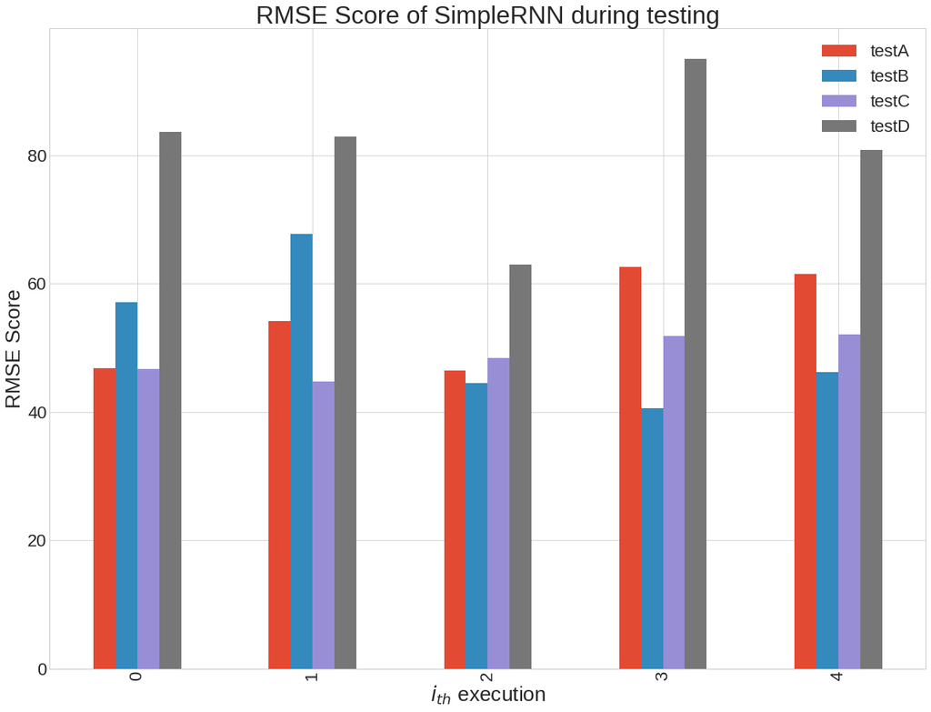

```python
# tiempos de test
ax = test_simple_testing.plot.bar()
ax.set_xlabel("$i_{th}$ execution")
ax.set_ylabel("RMSE Score")
ax.set_title('RMSE Score of SimpleRNN during testing')
```

### Conclusiones

En el caso de **D**, un dropout por sí solo añade ruido que no aporta a disminuir el error, dada la cantidad de épocas consideradas.